# Tarea 2: Clusters con Gaussian Mixed Models (GMM)

Equipo 9 - Aprendizaje no supervisado

2025-09-06

# Introducción.

Nuestro equipo ha estado analizando los datos de “loan approvals”, que contienen información sobre la aprobación o el rechazo de préstamos bancarios. Después de realizar el análisis exploratorio de datos y probar técnicas de reducción de dimensión, identificamos un desbalance en la distribución de los casos debido a lo siguiente:

1. Más del 99% de los créditos solicitados por personas con un score CIBIL mayor a 550 puntos fueron aprobados.
2. Más del 99% de los créditos solicitados por personas con un score CIBIL menor a 550 y con una fecha de término mayor a 4 fueron rechazados.

Al eliminar los casos descritos en los puntos 1 y 2, nuestra base de datos se reduce a aproximadamente 350 observaciones, en las que se presenta una mezcla proporcional entre aprobados y rechazados. Esto nos permitió notar que la cantidad de observaciones disponibles no es la ideal para la aplicación de algoritmos de clustering.

Ambos puntos se ilustran en la siguiente gráfica:

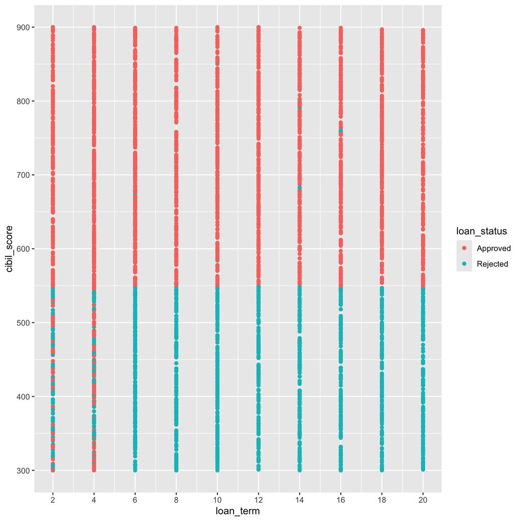

# Objetivo

Considerando los puntos descritos en la introducción, el objetivo de este ejercicio es analizar las observaciones con puntaje menor a 550 de “cibil” (~1,700 observaciones) y buscar agrupamientos (clusters) entre ellas utilizando GMM. Una vez identificados los clusters, se evaluará cuáles presentan una mayor tendencia a la aprobación y se compararán con aquellos que muestran un comportamiento más balanceado (más rechazo). El propósito de este análisis es comprender qué variables influyen en una mayor probabilidad de rechazo del crédito. Finalmente, se realizará una breve comparación con las variables relevantes obtenidas en un modelo de clasificación binaria de machine learning, con el fin de identificar coincidencias o al menos consistencia entre ambos enfoques.

# Tendencia a clustering de los datos

En esta sección presentaremos dos resultados que nos permitirán medir la tendencia de agrupamiento en nuestros datos: el estadístico de Hopkins y el método VAT (Visual Assessment of cluster Tendency).

## Estadísitico de Hopkings

```
## Hopkins Statistic Result: 0.9991
```

## Análisis visual de tedencia a Cluster (Visual Assessment of Cluster Tendency)

Notamos algunos sectores con tendencia a clustering.

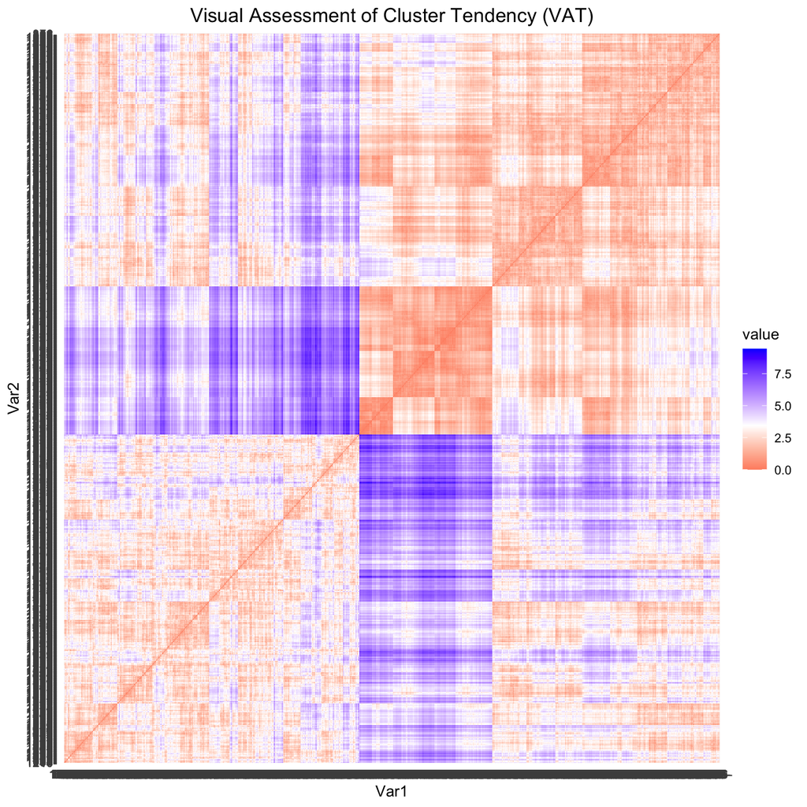

# Clusterización aplicando GMM

En esta sección calcularemos algunas métricas para evaluar el comportamiento del modelo GMM con diferentes números de clusters. Posteriormente, ajustaremos el modelo con el número de clusters considerado “ideal” y comentaremos los resultados obtenidos.

## Medidas para la selección de número de clusters

Las siguientes métricas se calcularon considerando un máximo de 4 clusters, ya que, debido a la cantidad de observaciones disponibles, la matriz resultó singular; es decir, el modelo no puede estimarse para un número mayor de clusters.

### Gráfico de codo (elbow chart)

Notamos una buena caída en la varianza acumulada al rededor de *K = 3 clusters*.

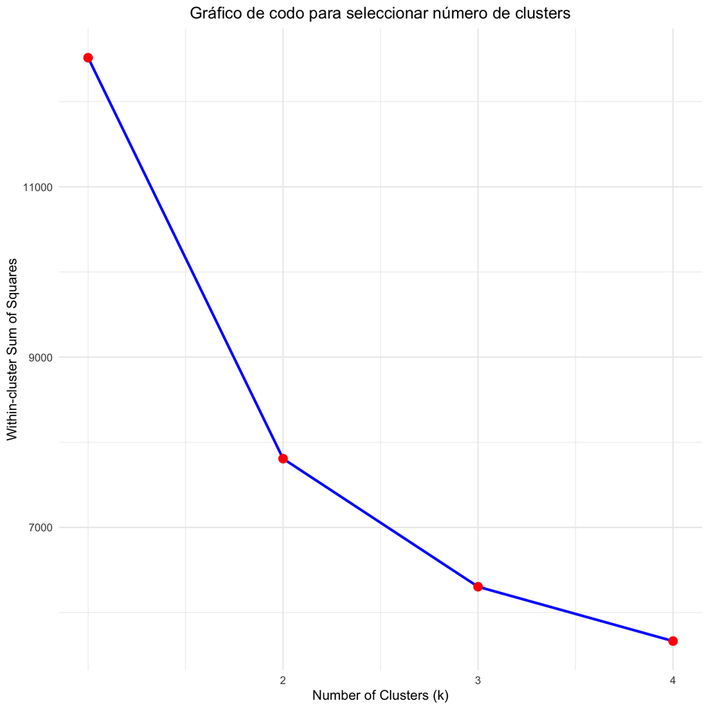

### Gráfico de “Silhouette average”

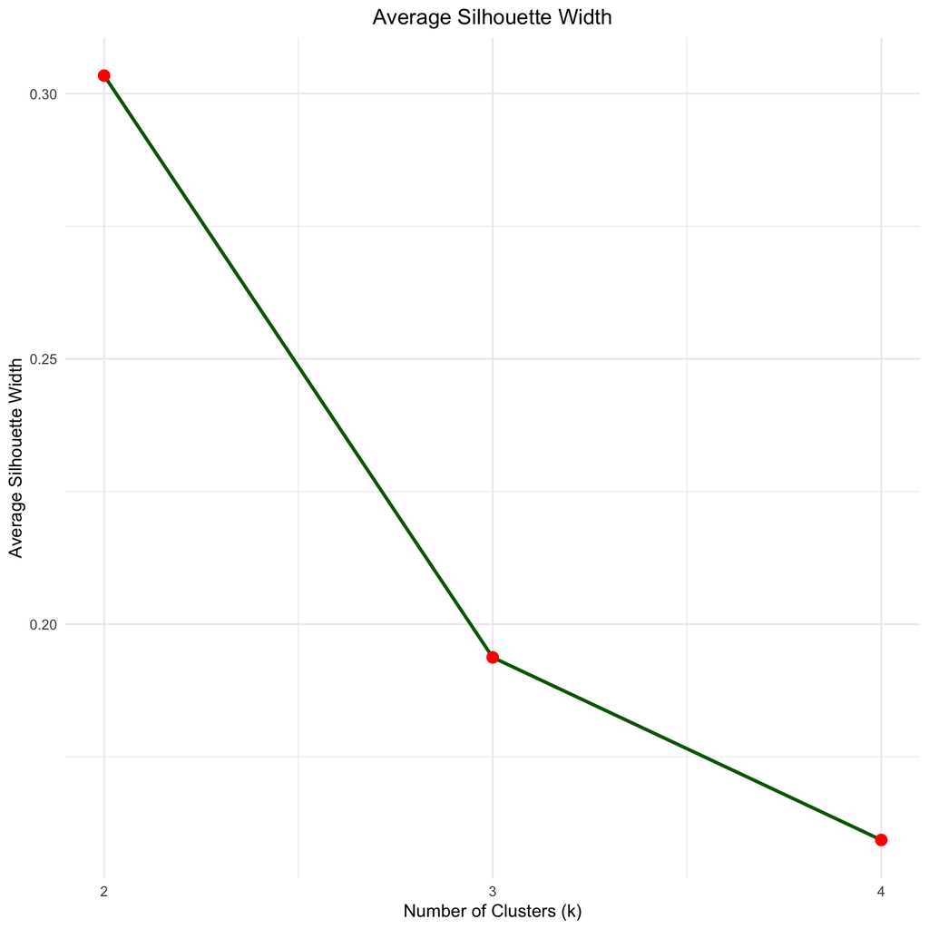

### Gráfico del estadístico “GAP”

El estadístico GAP llega a su “máximo” para *K = 3 clusters*.

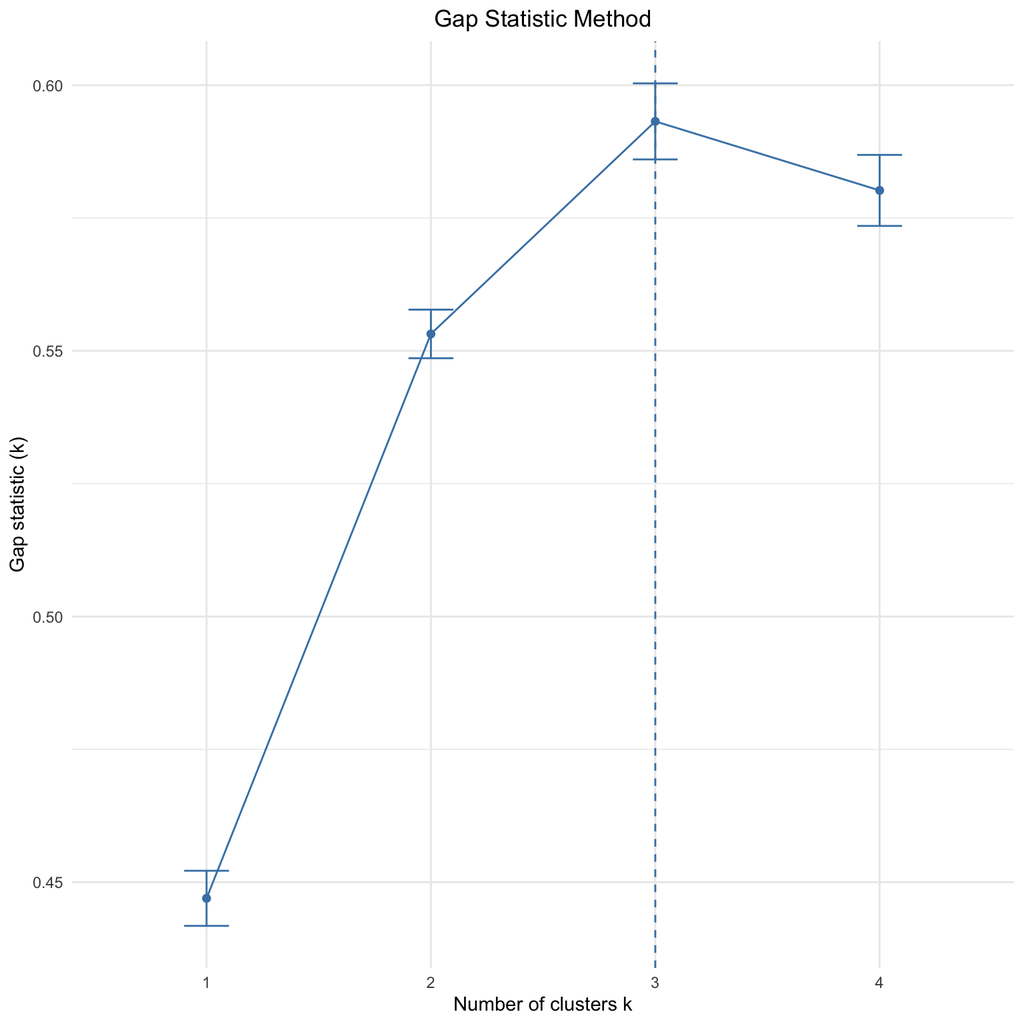

### Estadísticos BIC

La mayor diferencia en BIC se logra de 2 a 3 clusters, por lo que concluímos que *K = 3* es una buena elección.

```
##   clusters      BIC
## 1        1       NA
## 2        2 20435.54
## 3        3 19100.81
## 4        4 18967.77
```

## Clustering con GMM a 3 clusters.

Con base en los resultados obtenidos en la sección anterior, decidimos ajustar nuestro modelo GMM utilizando 3 clusters.

## Clusters vs. variable objetivo “loan_status”

Notamos que el cluster 1 (rojo) presenta una ligera sobre-representación de aprobaciones: 14% en comparación con el 10% observado en el total de los datos.

```
## # A tibble: 3 × 5
##   cluster Approved Approved_percent Rejected Rejected_percent
##     <dbl>    <dbl>            <dbl>    <dbl>            <dbl>
## 1       1       39            13.7       245             86.3
## 2       2       60             9.24      589             90.8
## 3       3       90            10.5       766             89.5
```

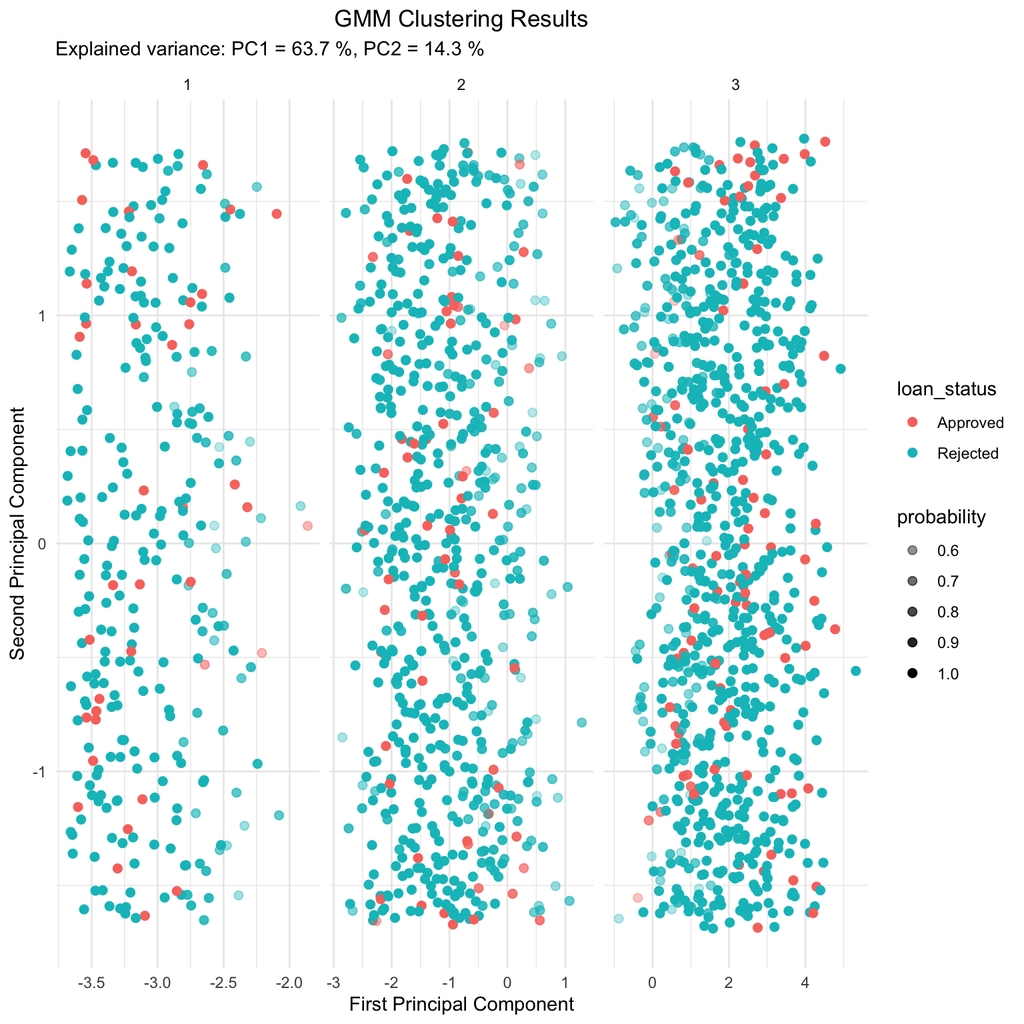

## Clusters en las variables

Al comparar el comportamiento del cluster 1 frente al resto de los clusters en cada variable (feature), observamos lo siguiente:

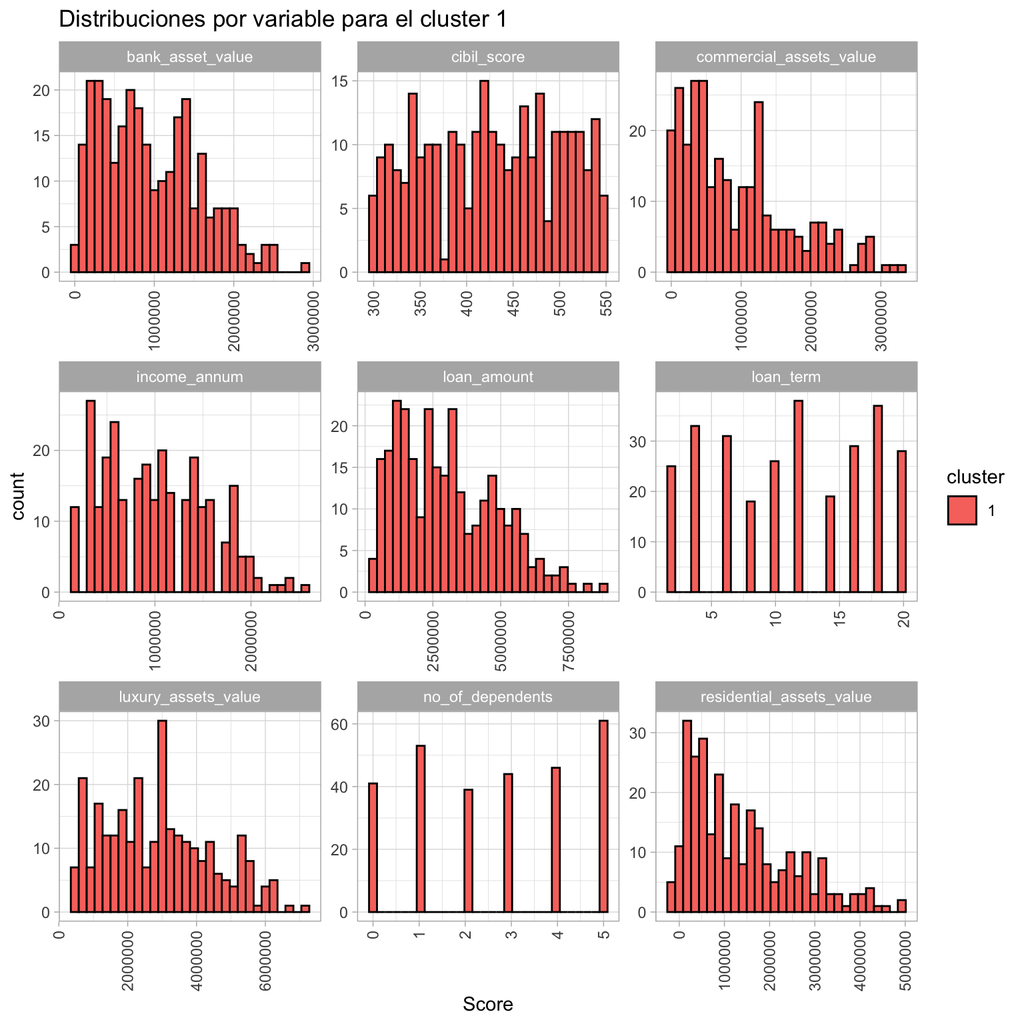

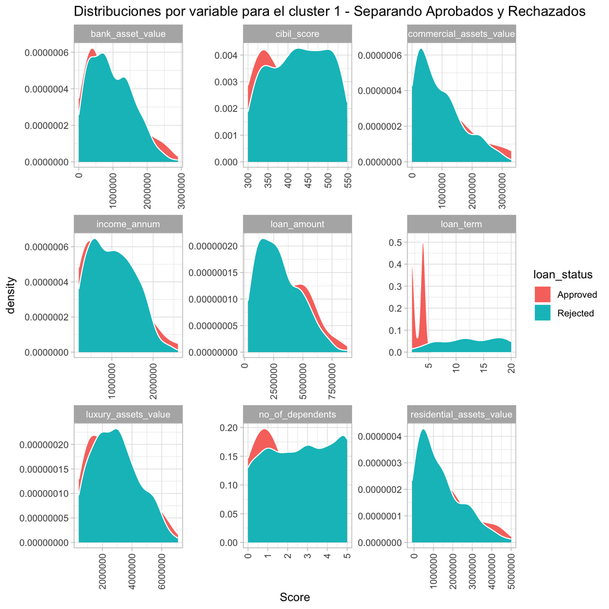

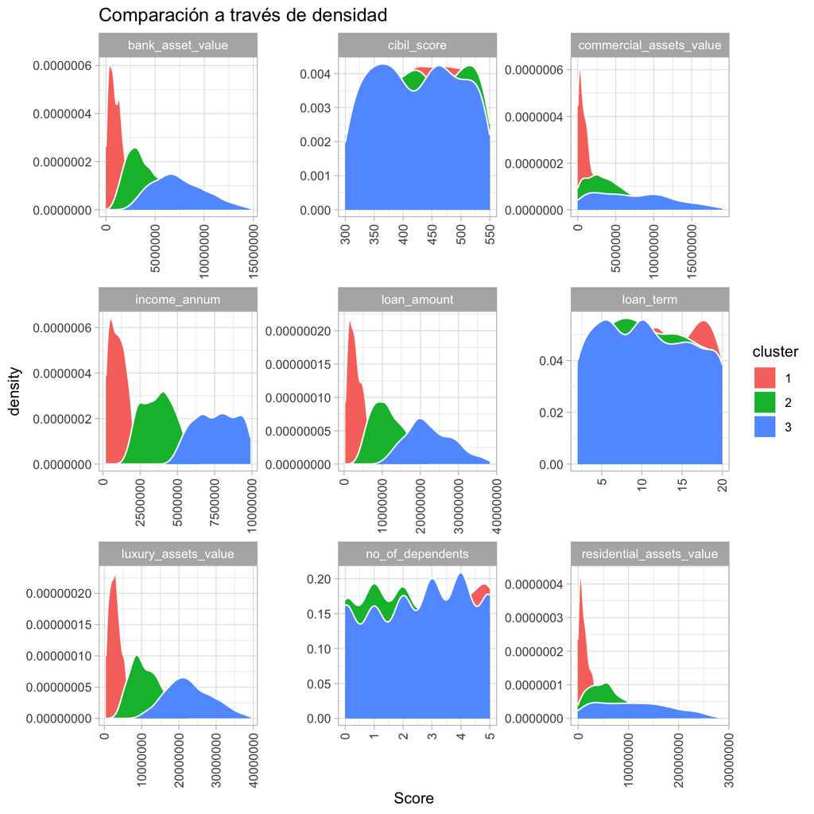

# Conclusiones